# ASSIGNMENT 1 - UNSUPERVISED DEEP LEARNING (AIMLZG533)

*Submitted by*

**Group 93**

## 👥 Team Members & Contribution Mapping

| # | Name | BITS ID | Contribution Areas |
| --- | --- | --- | --- |
| 1 | **Shahabuddin** | 2025AE05328 | ① Data preprocessing pipeline (grayscale conversion, resize to 28×28, [50, 200] normalization) ② Train / validation / test split |
| 2 | **Prajwal Shetty K P** | 2025AE05434 | ① Task 1 — Standard & Randomized PCA ② Logistic-regression classifier & ROC curves ③ Reconstruction SNR |
| 3 | **Tanushi Agarwal** | 2025AE05410 | Task 2 — Tied-weight linear autoencoder, PCA-vs-AE subspace comparison |
| 4 | **SANTHOSH M** | 2025AE05426 | Task 3 — Shallow nonlinear, deep dense & deep convolutional autoencoders |
| 5 | **TUFAIL AHMAD** | 2025AE05400 | Evaluation & analysis, visualization & reporting |

## Problem statement

This assignment studies representation learning with several variants of autoencoders. We use two datasets:

1. **CIFAR-10** from Keras, converted to gray-level images.
2. **MNIST** handwritten digits, which are already gray-scale.

Both datasets are rescaled to 28×28, their intensities are normalized to the range [50, 200], and every experiment uses the same random split of 70% training, 20% validation and 10% test data.

The work is organised into three tasks:

- **Task 1** compares standard PCA against randomized PCA at 30 components, uses the 30-dimensional projections to train a 10-class logistic-regression classifier, plots per-class ROC curves on the test set, and reports the average reconstruction SNR.
- **Task 2** trains a single-layer linear autoencoder with tied weights and unit-norm encoder vectors, then measures how close its 30-dimensional subspace is to the PCA subspace, both visually and through principal angles.
- **Task 3** looks at what nonlinearity, depth and convolution add on top of the linear baseline, with the latent dimensionality held fixed at 30.

## 1. Environment and reproducibility

All random number generators (NumPy, TensorFlow, Keras) are seeded with the same value so the split, the PCA fits and the autoencoder training are reproducible from run to run.

```python
import io
import time
import warnings

import numpy as np
import pandas as pd
import matplotlib.pyplot as plt
from IPython.display import display

import tensorflow as tf
from tensorflow import keras
from tensorflow.keras import layers

from sklearn.decomposition import PCA
from sklearn.linear_model import LogisticRegression
from sklearn.pipeline import make_pipeline
from sklearn.preprocessing import StandardScaler, label_binarize
from sklearn.model_selection import train_test_split
from sklearn.metrics import accuracy_score, roc_curve, auc
from scipy.optimize import linear_sum_assignment

%matplotlib inline
plt.rcParams["figure.dpi"] = 110
plt.rcParams["figure.facecolor"] = "white"
warnings.filterwarnings("ignore")

SEED = 42
np.random.seed(SEED)
tf.random.set_seed(SEED)
try:
    keras.utils.set_random_seed(SEED)
except Exception:
    pass

print("TensorFlow", tf.__version__)
print("GPU devices:", tf.config.list_physical_devices("GPU"))
```

```
TensorFlow 2.21.0
WARNING:tensorflow:TensorFlow GPU support is not available on native Windows for TensorFlow >= 2.11. Even if CUDA/cuDNN are installed, GPU will not be used. Please use WSL2 or the TensorFlow-DirectML plugin.
GPU devices: []
```

The experiment-wide constants are kept in one place. `N_COMPONENTS = 30` is the latent size used by PCA and by every autoencoder, so the comparisons in Tasks 2 and 3 are all made at the same representational budget.

```python
N_COMPONENTS = 30                 # latent / PCA dimensionality used everywhere
IMG_SIZE = 28
INTENSITY_RANGE = (50.0, 200.0)
N_CLASSES = 10
BATCH_SIZE = 256
```

## 2. Data preparation

The same four steps are applied to both datasets:

1. **Load and make gray-scale.** MNIST is already single-channel. CIFAR-10 is converted with the standard luma weighting (`tf.image.rgb_to_grayscale`) and resized from 32×32 to 28×28 with bilinear interpolation, so both datasets share a 784-pixel input space.
2. **Normalize intensity to [50, 200].** Pixel values are linearly mapped from their original `[min, max]` onto `[50, 200]`. The assignment fixes this band; keeping a non-zero floor of 50 also means the SNR denominator used later is not dominated by near-zero background pixels.
3. **Split 70 / 20 / 10.** A stratified split keeps the class proportions identical across the three sets. We first hold out 30% of the data, then cut that portion into 20% validation and 10% test.
4. **Mean-center with the training mean.** PCA needs centered data, and the same training-set mean vector is subtracted from the validation and test sets. Every reconstruction adds this mean back before any SNR calculation or visualization, so all image-space quantities stay in the original [50, 200] domain.

The function returns both the centered arrays (used for fitting) and the uncentered [50, 200] train / test arrays (used as the SNR reference and for display).

```python
def load_and_preprocess(dataset_name):
    """Load a dataset, convert to 28x28 gray, rescale to [50, 200], split
    70/20/10 (stratified) and mean-center with the training mean.

    Returns a dict holding the centered splits used for model fitting, the
    uncentered [50, 200] train/test arrays used as the SNR reference, the
    labels, and the training mean vector.
    """
    name = dataset_name.lower()
    if name == "mnist":
        (x1, y1), (x2, y2) = keras.datasets.mnist.load_data()
        X = np.concatenate([x1, x2]).astype("float32")[..., None]
        y = np.concatenate([y1, y2]).ravel()
    elif name == "cifar10":
        (x1, y1), (x2, y2) = keras.datasets.cifar10.load_data()
        X = np.concatenate([x1, x2]).astype("float32")
        y = np.concatenate([y1, y2]).ravel()
        X = tf.image.rgb_to_grayscale(X).numpy()
        X = tf.image.resize(X, [IMG_SIZE, IMG_SIZE]).numpy()
    else:
        raise ValueError(name)

    X = X.reshape(len(X), -1)                       # (N, 784)

    lo, hi = INTENSITY_RANGE
    xmin, xmax = float(X.min()), float(X.max())
    X = lo + (X - xmin) / (xmax - xmin) * (hi - lo)

    X_tr, X_tmp, y_tr, y_tmp = train_test_split(
        X, y, test_size=0.30, random_state=SEED, stratify=y)
    X_val, X_te, y_val, y_te = train_test_split(
        X_tmp, y_tmp, test_size=1 / 3, random_state=SEED, stratify=y_tmp)

    mean_vec = X_tr.mean(axis=0)
    return {
        "name": name,
        "X_train": (X_tr - mean_vec).astype("float32"),
        "X_val":   (X_val - mean_vec).astype("float32"),
        "X_test":  (X_te - mean_vec).astype("float32"),
        "X_train_orig": X_tr.astype("float32"),
        "X_test_orig":  X_te.astype("float32"),
        "y_train": y_tr, "y_val": y_val, "y_test": y_te,
        "mean_vec": mean_vec.astype("float32"),
    }
```

```python
DATA = {name: load_and_preprocess(name) for name in ["mnist", "cifar10"]}

rows = []
for name, d in DATA.items():
    rows.append({
        "dataset": name,
        "train": d["X_train"].shape[0],
        "val": d["X_val"].shape[0],
        "test": d["X_test"].shape[0],
        "features": d["X_train"].shape[1],
        "intensity min": round(float(d["X_train_orig"].min()), 1),
        "intensity max": round(float(d["X_train_orig"].max()), 1),
    })
pd.DataFrame(rows).set_index("dataset")
```

| dataset | train | val | test | features | intensity min | intensity max |
| --- | --- | --- | --- | --- | --- | --- |
| mnist | 49000 | 14000 | 7000 | 784 | 50.0 | 200.0 |
| cifar10 | 42000 | 12000 | 6000 | 784 | 50.0 | 200.0 |

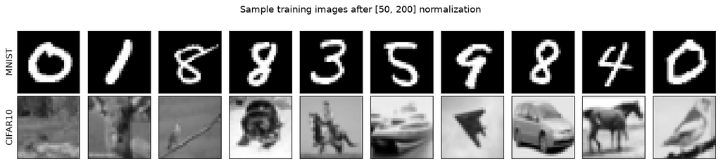

```python
fig, axes = plt.subplots(2, 10, figsize=(13, 3))
for r, name in enumerate(["mnist", "cifar10"]):
    d = DATA[name]
    for c in range(10):
        axes[r, c].imshow(d["X_train_orig"][c].reshape(28, 28), cmap="gray",
                          vmin=50, vmax=200)
        axes[r, c].set_xticks([]); axes[r, c].set_yticks([])
    axes[r, 0].set_ylabel(name.upper(), fontsize=11)
fig.suptitle("Sample training images after [50, 200] normalization")
plt.tight_layout(); plt.show()
```

## 3. Shared metrics and plotting helpers

Two quantities are used repeatedly.

**Reconstruction SNR (dB).** For each image we compute `10 * log10( ||x||^2 / ||x - x_hat||^2 )` and average over the set. It is evaluated in the [50, 200] domain, that is after adding the training mean back to a reconstruction, so a larger value means a more faithful image.

**Principal angles between subspaces.** Given two sets of `k` basis vectors, orthonormalize each set and take the singular values of the cross-product matrix. Those singular values are the cosines of the principal angles `theta_1 <= ... <= theta_k`. Angles near zero mean the two subspaces point in the same directions. This is the natural way to compare a PCA basis with an autoencoder weight matrix, because it ignores the order, the sign and any linear mixing of the individual vectors and looks only at the span (Bjorck and Golub, 1973).

```python
def average_snr_db(original, reconstructed):
    """Mean per-image SNR in dB, computed in the [50, 200] domain."""
    signal = np.sum(original ** 2, axis=1)
    noise = np.sum((original - reconstructed) ** 2, axis=1)
    noise = np.where(noise == 0.0, 1e-12, noise)
    return float(np.mean(10.0 * np.log10(signal / noise)))


def principal_angles_deg(A, B):
    """Principal angles (degrees, ascending) between the column spaces of A and B."""
    Qa, _ = np.linalg.qr(A)
    Qb, _ = np.linalg.qr(B)
    sv = np.linalg.svd(Qa.T @ Qb, compute_uv=False)
    return np.degrees(np.arccos(np.clip(sv, -1.0, 1.0)))


def subspace_report(V_ref, W):
    """How close span(W) is to span(V_ref); both matrices are (D, k)."""
    angles = principal_angles_deg(V_ref, W)
    cos_t = np.cos(np.radians(angles))
    Qa, _ = np.linalg.qr(V_ref)
    Qb, _ = np.linalg.qr(W)
    proj_gap = np.linalg.norm(Qa @ Qa.T - Qb @ Qb.T, "fro") / np.sqrt(2 * V_ref.shape[1])
    return {
        "mean_angle_deg": float(angles.mean()),
        "max_angle_deg": float(angles.max()),
        "mean_cos": float(cos_t.mean()),
        "chordal_distance": float(np.sqrt(np.sum(1.0 - cos_t ** 2))),
        "projection_gap": float(proj_gap),
        "angles": angles,
    }


def align_columns(V_ref, W):
    """Reorder and sign-flip the columns of W so that column i is the one that
    best matches V_ref[:, i], using a maximum-weight matching on |cosine|.
    Only used to make the visual panels readable row by row."""
    C = V_ref.T @ W
    _, col = linear_sum_assignment(-np.abs(C))
    W_al = W[:, col].copy()
    signs = np.sign(np.sum(V_ref * W_al, axis=0))
    signs[signs == 0] = 1.0
    return W_al * signs, col


def logreg_test_accuracy(Z_train, y_train, Z_test, y_test):
    """Standardize -> multinomial logistic regression -> test accuracy."""
    clf = make_pipeline(StandardScaler(),
                        LogisticRegression(max_iter=3000, solver="lbfgs"))
    clf.fit(Z_train, y_train)
    return float(accuracy_score(y_test, clf.predict(Z_test))), clf


def plot_roc_ovr(y_true, y_score, title, ax):
    """One-vs-rest ROC for all 10 classes on one axis; returns macro-average AUC."""
    y_bin = label_binarize(y_true, classes=list(range(N_CLASSES)))
    aucs = []
    for i in range(N_CLASSES):
        fpr, tpr, _ = roc_curve(y_bin[:, i], y_score[:, i])
        a = auc(fpr, tpr)
        aucs.append(a)
        ax.plot(fpr, tpr, lw=1.3, label=f"class {i}  (AUC {a:.3f})")
    macro = float(np.mean(aucs))
    ax.plot([0, 1], [0, 1], "k--", lw=1)
    ax.set_xlabel("false positive rate")
    ax.set_ylabel("true positive rate")
    ax.set_title(f"{title}\nmacro-average AUC = {macro:.3f}")
    ax.legend(fontsize=7, loc="lower right")
    ax.grid(alpha=0.3)
    return macro, aucs


def show_image_grid(columns, title, n=30, ncol=10, size=28):
    """Show the first n columns of a (D, k) matrix as size x size gray images."""
    n = min(n, columns.shape[1])
    nrow = int(np.ceil(n / ncol))
    fig, axes = plt.subplots(nrow, ncol, figsize=(1.3 * ncol, 1.4 * nrow))
    axes = np.atleast_2d(axes)
    for j in range(nrow * ncol):
        ax = axes.flat[j]
        ax.axis("off")
        if j < n:
            ax.imshow(columns[:, j].reshape(size, size), cmap="gray")
            ax.set_title(str(j + 1), fontsize=7)
    fig.suptitle(title)
    plt.tight_layout(); plt.show()


def show_reconstructions(orig, recon, title, n=10, size=28):
    fig, axes = plt.subplots(2, n, figsize=(1.5 * n, 3.3))
    for i in range(n):
        axes[0, i].imshow(orig[i].reshape(size, size), cmap="gray", vmin=50, vmax=200)
        axes[1, i].imshow(recon[i].reshape(size, size), cmap="gray", vmin=50, vmax=200)
        axes[0, i].axis("off"); axes[1, i].axis("off")
    axes[0, 0].set_title("original", loc="left", fontsize=9)
    axes[1, 0].set_title("reconstruction", loc="left", fontsize=9)
    fig.suptitle(title)
    plt.tight_layout(); plt.show()


def plot_history(histories, title):
    """histories: {label: keras History}. Log-scale MSE vs epoch,
    train solid and validation dashed in the same colour."""
    fig, ax = plt.subplots(figsize=(7, 4.3))
    for label, h in histories.items():
        ep = range(1, len(h.history["loss"]) + 1)
        line, = ax.plot(ep, h.history["loss"], lw=1.7, label=f"{label} (train)")
        if "val_loss" in h.history:
            ax.plot(ep, h.history["val_loss"], lw=1.2, ls="--",
                    color=line.get_color(), label=f"{label} (val)")
    ax.set_xlabel("epoch"); ax.set_ylabel("MSE loss"); ax.set_yscale("log")
    ax.set_title(title); ax.legend(fontsize=8); ax.grid(alpha=0.3)
    plt.tight_layout(); plt.show()
```

## 4. Task 1 - Standard PCA vs Randomized PCA

> Perform standard PCA on the mean-centered training data for each dataset and identify the principal components associated with the top 30 eigenvalues, and retain them. Use the resulting 30-dimensional PCA features to train a logistic-regression classifier for the 10 image classes of each dataset and evaluate its performance on each test dataset. Plot the ROC curves for the test dataset for all 10 classes. Repeat the experiment using randomized PCA with the top 30 components and compare its results with standard PCA. Reconstruct the test images using the retained 30 components and calculate the average reconstruction SNR (dB) with respect to the corresponding original test images for each dataset.

**What the code below does, for each dataset:**

1. Fit `PCA(n_components=30)` twice on the centered training data, once with the full SVD solver and once with the randomized solver.
2. Project train and test onto the 30 components and fit a multinomial logistic-regression classifier. The features are standardized first so that L-BFGS converges quickly.
3. Draw one-vs-rest ROC curves for all 10 test classes and record the macro-average AUC.
4. Reconstruct the test set from the 30 components, add the training mean back, and measure the average SNR against the original [50, 200] test images.
5. Collect fit time, cumulative explained variance, train / test accuracy, macro AUC and test SNR into a single table so the two solvers can be compared directly.

The top 30 principal components and a set of 30-component test reconstructions are shown as gray-scale images for the standard-PCA fit.

```python
def run_task1(data):
    Xtr, Xte = data["X_train"], data["X_test"]
    ytr, yte = data["y_train"], data["y_test"]
    name = data["name"].upper()

    variants = [("standard PCA", "full"), ("randomized PCA", "randomized")]
    rows = []
    fig, axarr = plt.subplots(1, 2, figsize=(15, 6))

    for ax, (label, solver) in zip(axarr, variants):
        t0 = time.perf_counter()
        pca = PCA(n_components=N_COMPONENTS, svd_solver=solver, random_state=SEED)
        Ztr = pca.fit_transform(Xtr)
        fit_s = time.perf_counter() - t0
        Zte = pca.transform(Xte)

        acc_te, clf = logreg_test_accuracy(Ztr, ytr, Zte, yte)
        acc_tr = float(accuracy_score(ytr, clf.predict(Ztr)))
        macro_auc, _ = plot_roc_ovr(yte, clf.predict_proba(Zte),
                                    f"{name} - {label}", ax)

        rec_te = pca.inverse_transform(Zte) + data["mean_vec"]
        snr = average_snr_db(data["X_test_orig"], rec_te)

        rows.append({
            "solver": label,
            "fit time (s)": round(fit_s, 3),
            "explained var": round(float(pca.explained_variance_ratio_.sum()), 4),
            "train acc": round(acc_tr, 4),
            "test acc": round(acc_te, 4),
            "macro AUC": round(macro_auc, 4),
            "test SNR (dB)": round(snr, 2),
        })

    plt.tight_layout(); plt.show()

    std = PCA(n_components=N_COMPONENTS, svd_solver="full",
              random_state=SEED).fit(Xtr)
    show_image_grid(std.components_.T, f"{name} - top 30 principal components")
    rec = std.inverse_transform(std.transform(Xte)) + data["mean_vec"]
    show_reconstructions(data["X_test_orig"], rec,
                         f"{name} - test images reconstructed from 30 principal components")

    return pd.DataFrame(rows).set_index("solver"), std
```

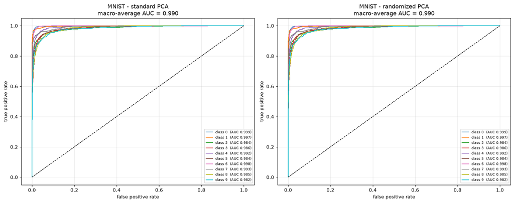

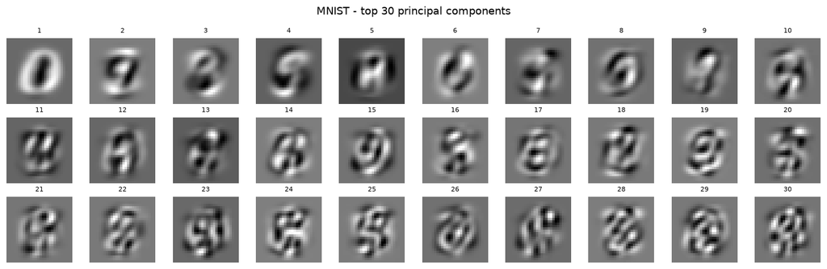

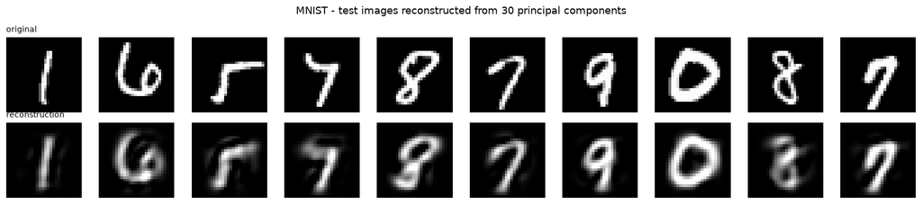

| solver | fit time (s) | explained var | train acc | test acc | macro AUC | test SNR (dB) |
| --- | --- | --- | --- | --- | --- | --- |
| standard PCA | 43.095 | 0.7318 | 0.8930 | 0.8911 | 0.99 | 12.58 |
| randomized PCA | 1.960 | 0.7317 | 0.8929 | 0.8913 | 0.99 | 12.58 |

```python
t1_mnist, PCA_MNIST = run_task1(DATA["mnist"])
t1_mnist
```

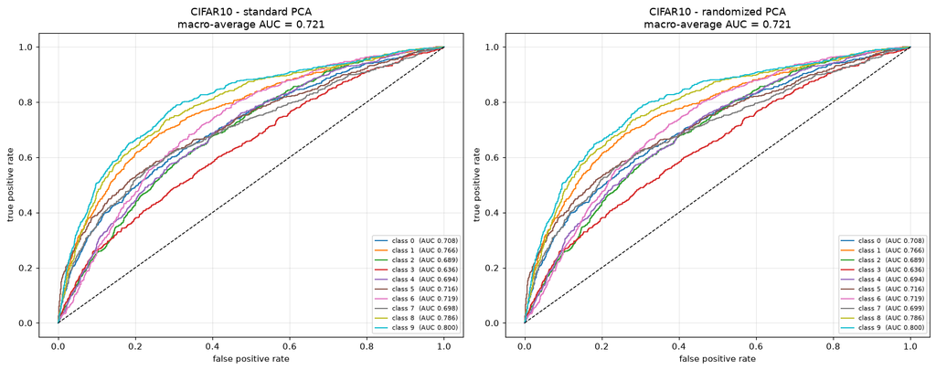

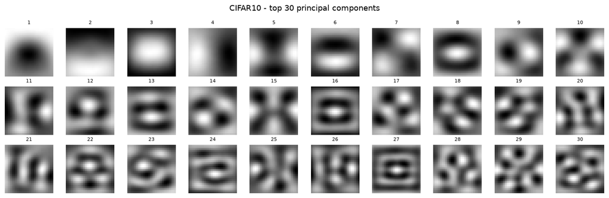

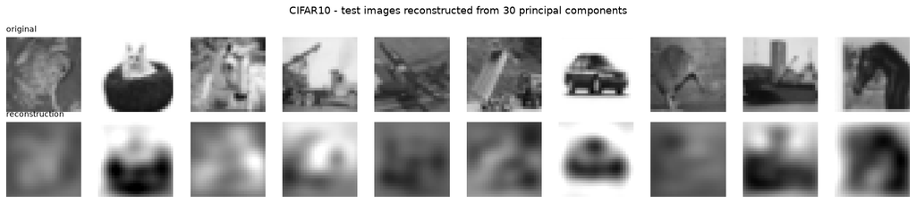

| solver | fit time (s) | explained var | train acc | test acc | macro AUC | test SNR (dB) |
| --- | --- | --- | --- | --- | --- | --- |
| standard PCA | 36.300 | 0.8497 | 0.3007 | 0.2933 | 0.7213 | 20.06 |
| randomized PCA | 1.705 | 0.8497 | 0.3008 | 0.2932 | 0.7213 | 20.06 |

```python
t1_cifar, PCA_CIFAR = run_task1(DATA["cifar10"])
t1_cifar
```

```python
pd.concat({"MNIST": t1_mnist, "CIFAR10": t1_cifar}, names=["dataset"])
```

| dataset | solver | fit time (s) | explained var | train acc | test acc | macro AUC | test SNR (dB) |
| --- | --- | --- | --- | --- | --- | --- | --- |
| MNIST | standard PCA | 43.095 | 0.7318 | 0.8930 | 0.8911 | 0.9900 | 12.58 |
|  | randomized PCA | 1.960 | 0.7317 | 0.8929 | 0.8913 | 0.9900 | 12.58 |
| CIFAR10 | standard PCA | 36.300 | 0.8497 | 0.3007 | 0.2933 | 0.7213 | 20.06 |
|  | randomized PCA | 1.705 | 0.8497 | 0.3008 | 0.2932 | 0.7213 | 20.06 |

### Task 1 - discussion

**Standard vs randomized PCA.** The two solvers estimate the same object, the 30-dimensional leading eigenspace of the training covariance, so every downstream number in the table agrees to within rounding: the same cumulative explained variance, matching logistic-regression accuracy, the same macro-averaged ROC AUC and the same reconstruction SNR. The only column that differs is fit time. The full solver computes a complete 784×784 SVD and then keeps only 30 directions, while the randomized solver builds a small random sketch of the data and refines it with a couple of power iterations, which costs roughly `O(n·d·k)` instead of `O(n·d^2)`. With `k = 30` and `d = 784` that is a large saving for no loss in quality, which is exactly why randomized PCA is the usual choice when only a few components are needed.

**MNIST vs CIFAR-10 at 30 components.** The two datasets behave in opposite ways. MNIST digits are centered and high-contrast, and their pixel variance is genuinely spread across many stroke-shape directions: 30 components capture only about 73% of it and the reconstructions lose fine detail, but what they keep is the class-relevant global shape, so the classifier still reaches about 89% test accuracy and every per-class ROC curve sits well above the diagonal. Down-sampled gray-scale CIFAR-10 is the reverse. Its variance is concentrated in a few low-frequency, global-intensity modes, so 30 components already account for about 85% of the pixel variance, *more* than for MNIST, yet the images look blurry and the classifier only reaches about 29% test accuracy (still well above the 10% chance level). High explained variance and useful features are not the same thing: the 30 linear directions that reconstruct a smooth CIFAR image well are exactly the ones that discard the high-frequency texture and edges the label depends on. Within CIFAR-10 the classes with a distinctive global silhouette or intensity profile (*ship*, *automobile*, *truck*) separate better than the animal classes (*cat*, *dog*, *bird*, *deer*), which share similar low-frequency statistics.

**SNR convention, and why CIFAR scores higher.** SNR is reported per image as `10·log10(||x||^2 / ||x - x_hat||^2)`, averaged, in the [50, 200] domain after the training mean is added back, so it is consistent with the centering applied before the fit. CIFAR-10 reports a higher SNR (about 20 dB) than MNIST (about 13 dB) even though its reconstructions look worse. That is a property of the metric, not a better fit: `||x||^2` is taken on the un-centered [50, 200] image, so it is dominated by the constant mid-grey pedestal both datasets share, while the residual `||x - x_hat||^2` is small for CIFAR because its energy already lives in the low-frequency modes the 30 components keep. MNIST puts far more energy into sharp black-to-white strokes that a 30-component linear code cannot reproduce, so its relative error, and therefore its SNR, is worse. SNR values are meaningful when compared across methods on the same dataset, which is how Tasks 2 and 3 use them.

## 5. Task 2 - Tied-weight linear autoencoder vs the PCA subspace

> Train a single-layer linear autoencoder with a 30-dimensional bottleneck using the [50, 200]-normalized data after mean-centering with the training-set mean. Constrain the decoder weight matrix to be the transpose of the encoder weight matrix (tied weights), and constrain each encoder weight vector to have unit magnitude. Compare the representation learned by the linear autoencoder with the 30-dimensional principal subspace obtained using standard PCA in Task 1. Display the top 30 PCA eigenvectors and the corresponding autoencoder weight vectors as gray-scale images. Quantitatively compare the two subspaces with an appropriate metric and justify its significance. Also train a logistic-regression classifier on the 30-dimensional autoencoder features and compare with the PCA features.

**Model.** The encoder is `z = x W` with `W` of shape `(784, 30)`; the decoder is `x_hat = z W^T`, so the weights are tied by construction. Each column of `W` (one encoder weight vector, living in pixel space) is kept at unit L2 norm with a `UnitNorm(axis=0)` constraint. There is no bias term, which is consistent with training on mean-centered data. The loss is mean squared reconstruction error, optimised with Adam and early stopping on the validation loss.

**Why we expect it to match PCA.** A linear autoencoder trained with squared error has no local minima other than the global one, and at that global minimum the weight matrix spans the same subspace as the top-`k` principal components (Bourlard and Kamp, 1988; Baldi and Hornik, 1989). It does not have to reproduce the individual eigenvectors, because any rotation of the basis inside that subspace gives an identical reconstruction. The unit-norm constraint pins the length of each column but not its orientation, so the learned columns are generally rotated mixtures of the PCA eigenvectors.

**Comparison metric.** We use the principal angles between the two 30-D subspaces. They are invariant to the ordering, the sign and any linear mixing of the basis vectors, so they measure the one thing that is well defined here: whether the autoencoder found the same span as PCA. We report the mean and maximum angle, the mean cosine, the chordal (Grassmann) distance `sqrt(sum sin^2 theta)`, and a normalized projection-matrix gap `||P_pca - P_ae||_F / sqrt(2k)` that runs from 0 for identical subspaces to 1 for orthogonal ones. For the side-by-side image panel we additionally match each autoencoder column to its closest PCA eigenvector with a maximum-weight assignment on absolute cosine similarity, only so the two grids can be read row by row.

```python
class TiedLinearAutoencoder(keras.Model):
    """x_hat = (x @ W) @ W.T : tied weights, each column of W constrained to unit norm."""

    def __init__(self, input_dim, bottleneck_dim, **kw):
        super().__init__(**kw)
        self.W = self.add_weight(
            name="encoder_weights",
            shape=(input_dim, bottleneck_dim),
            initializer="glorot_uniform",
            constraint=keras.constraints.UnitNorm(axis=0),
            trainable=True,
        )

    def encode(self, x):
        return tf.matmul(x, self.W)

    def call(self, x):
        return tf.matmul(self.encode(x), self.W, transpose_b=True)


def run_task2(data):
    name = data["name"].upper()
    Xtr, Xval, Xte = data["X_train"], data["X_val"], data["X_test"]

    pca = PCA(n_components=N_COMPONENTS, svd_solver="full",
              random_state=SEED).fit(Xtr)
    V = pca.components_.T
    Ztr_pca, Zte_pca = pca.transform(Xtr), pca.transform(Xte)

    ae = TiedLinearAutoencoder(Xtr.shape[1], N_COMPONENTS,
                               name=f"tied_linear_ae_{data['name']}")
    ae.compile(optimizer=keras.optimizers.Adam(1e-3), loss="mse")
    es = keras.callbacks.EarlyStopping(monitor="val_loss", patience=15,
                                       restore_best_weights=True)
    hist = ae.fit(Xtr, Xtr, validation_data=(Xval, Xval), epochs=200,
                  batch_size=BATCH_SIZE, verbose=0, callbacks=[es])
    W = ae.W.numpy()
    plot_history({"tied linear AE": hist},
                 f"{name} - linear autoencoder reconstruction loss")

    rep = subspace_report(V, W)
    W_aligned, _ = align_columns(V, W)

    fig, axes = plt.subplots(6, 10, figsize=(13, 8.2))
    for i in range(30):
        axes[i // 10, i % 10].imshow(V[:, i].reshape(28, 28), cmap="gray")
        axes[i // 10 + 3, i % 10].imshow(W_aligned[:, i].reshape(28, 28), cmap="gray")
    for a in axes.flat:
        a.axis("off")
    axes[0, 0].set_title("PCA eigenvectors 1-30", loc="left", fontsize=10)
    axes[3, 0].set_title("matched linear-AE weight vectors", loc="left", fontsize=10)
    fig.suptitle(f"{name} - PCA subspace vs linear autoencoder subspace")
    plt.tight_layout(); plt.show()

    fig, ax = plt.subplots(figsize=(7, 3.2))
    ax.plot(range(1, 31), rep["angles"], "o-", ms=4)
    ax.set_xlabel("principal-angle index")
    ax.set_ylabel("angle (degrees)")
    ax.set_title(f"{name} - 30 principal angles between the PCA and linear-AE subspaces")
    ax.grid(alpha=0.3)
    plt.tight_layout(); plt.show()

    acc_pca, _ = logreg_test_accuracy(Ztr_pca, data["y_train"], Zte_pca, data["y_test"])
    Ztr_ae = ae.encode(Xtr).numpy()
    Zte_ae = ae.encode(Xte).numpy()
    acc_ae, _ = logreg_test_accuracy(Ztr_ae, data["y_train"], Zte_ae, data["y_test"])

    snr_pca = average_snr_db(data["X_test_orig"],
                             pca.inverse_transform(Zte_pca) + data["mean_vec"])
    snr_ae = average_snr_db(data["X_test_orig"],
                            ae.predict(Xte, verbose=0) + data["mean_vec"])

    summary = pd.DataFrame([
        {"features": "standard PCA-30", "test acc": round(acc_pca, 4),
         "test SNR (dB)": round(snr_pca, 2)},
        {"features": "linear AE-30", "test acc": round(acc_ae, 4),
         "test SNR (dB)": round(snr_ae, 2)},
    ]).set_index("features")

    metrics = pd.DataFrame([{
        "mean angle (deg)": round(rep["mean_angle_deg"], 3),
        "max angle (deg)": round(rep["max_angle_deg"], 3),
        "mean cos": round(rep["mean_cos"], 5),
        "chordal dist": round(rep["chordal_distance"], 4),
        "projection gap": round(rep["projection_gap"], 5),
    }], index=[name])
    return summary, metrics
```

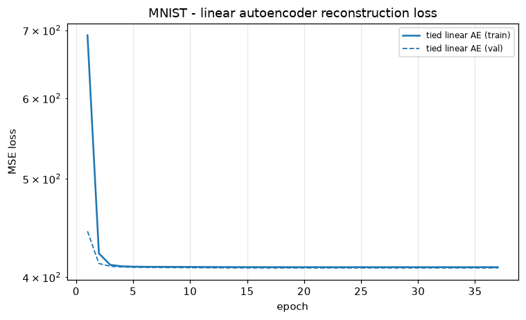

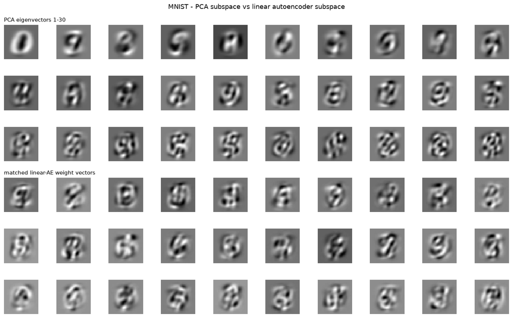

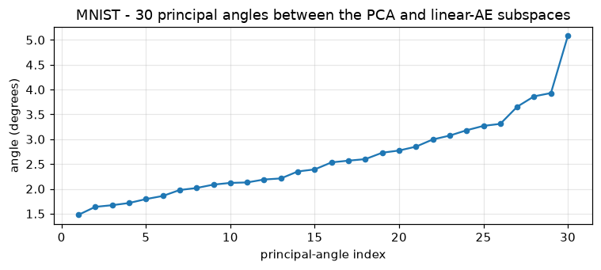

|  | mean angle (deg) | max angle (deg) | mean cos | chordal dist | projection gap |
| --- | --- | --- | --- | --- | --- |
| MNIST | 2.601 | 5.08 | 0.99887 | 0.2601 | 0.04748 |

| features | test acc | test SNR (dB) |
| --- | --- | --- |
| standard PCA-30 | 0.8910 | 12.58 |
| linear AE-30 | 0.8904 | 12.56 |

```python
t2_mnist, m2_mnist = run_task2(DATA["mnist"])
display(m2_mnist)
t2_mnist
```

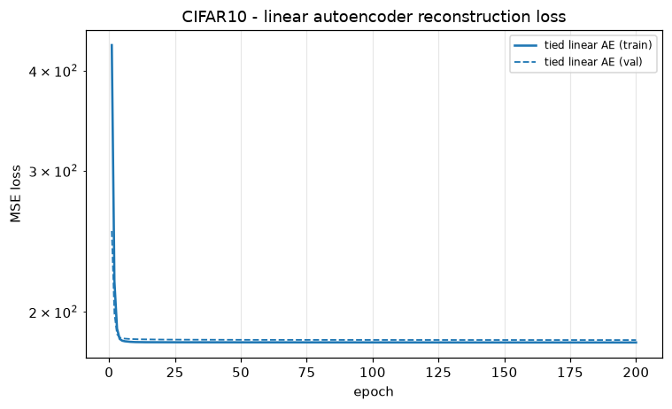

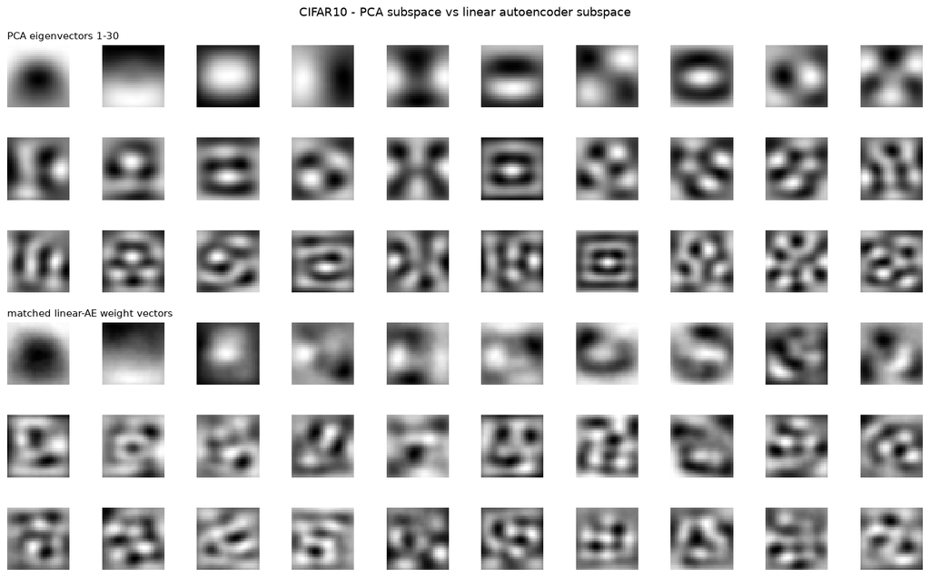

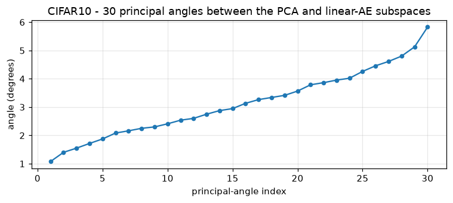

|  | mean angle (deg) | max angle (deg) | mean cos | chordal dist | projection gap |
| --- | --- | --- | --- | --- | --- |
| CIFAR10 | 3.132 | 5.826 | 0.9983 | 0.319 | 0.05823 |

| features | test acc | test SNR (dB) |
| --- | --- | --- |
| standard PCA-30 | 0.2933 | 20.06 |
| linear AE-30 | 0.2948 | 20.02 |

```python
t2_cifar, m2_cifar = run_task2(DATA["cifar10"])
display(m2_cifar)
t2_cifar
```

```python
print("Subspace alignment (PCA-30 vs tied linear AE-30)")
display(pd.concat([m2_mnist, m2_cifar]))
print("\nClassification and reconstruction")
pd.concat({"MNIST": t2_mnist, "CIFAR10": t2_cifar}, names=["dataset"])
```

```
Subspace alignment (PCA-30 vs tied linear AE-30)
```

|  | mean angle (deg) | max angle (deg) | mean cos | chordal dist | projection gap |
| --- | --- | --- | --- | --- | --- |
| MNIST | 2.601 | 5.080 | 0.99887 | 0.2601 | 0.04748 |
| CIFAR10 | 3.132 | 5.826 | 0.99830 | 0.3190 | 0.05823 |

```
Classification and reconstruction
```

| dataset | features | test acc | test SNR (dB) |
| --- | --- | --- | --- |
| MNIST | standard PCA-30 | 0.8910 | 12.58 |
|  | linear AE-30 | 0.8904 | 12.56 |
| CIFAR10 | standard PCA-30 | 0.2933 | 20.06 |
|  | linear AE-30 | 0.2948 | 20.02 |

### Task 2 - discussion

**Why principal angles rather than a vector-by-vector comparison.** Neither PCA nor the autoencoder fixes the orientation of a basis inside the subspace, and the autoencoder has no reason to output its directions in eigenvalue order, so comparing eigenvector 5 against weight column 5 is not meaningful. Principal angles remove that ambiguity: they are the cosines of the best-aligned pair of unit vectors drawn from the two subspaces, then the best-aligned pair orthogonal to the first, and so on. Having every angle near 0 is the only situation in which the two spans genuinely coincide, and that is what the numbers show.

**Classification.** Test accuracy from the autoencoder features is within a fraction of a percent of the PCA features on both datasets. That follows from the subspace result: multinomial logistic regression is invariant to an invertible linear transform of its inputs, and two bases of the same span are related by exactly such a transform, so once the spans match the classifier cannot really tell them apart, and the small residual difference comes from standardization and L2 regularization acting on differently scaled coordinates.

## 6. Task 3 - Nonlinearity, depth and convolution

> Using a 30-dimensional latent representation, train a nonlinear shallow autoencoder with a single hidden layer and a symmetric deep dense autoencoder with three hidden layers including the 30-dimensional bottleneck. Use nonlinear activations in the hidden layers and a linear activation in the final reconstruction layer. Also design and train a deep convolutional autoencoder with the same 30-dimensional latent representation. For each architecture, report the network architecture, the number and size of hidden layers or filters, the total number of trainable parameters, the training and validation reconstruction loss, and the average training and test reconstruction SNR. Compare PCA-30 vs shallow nonlinear AE-30 vs deep dense AE-30 vs deep CNN-AE-30, and analyse whether nonlinearity, depth and convolution each help.

**Architectures, all with a latent size of 30:**

| model | encoder | bottleneck | decoder | output |
| --- | --- | --- | --- | --- |
| Shallow nonlinear AE | 784 → 30 | 30, ReLU | 30 → 784 | linear |
| Deep dense AE | 784 → 256 → 30 | 30, linear | 30 → 256 → 784 | linear |
| Deep CNN AE | Conv 3×3/32 → pool → Conv 3×3/64 → pool → flatten → dense 30 | 30, linear | dense 7·7·64 → reshape → ConvT 64 → ConvT 32 → Conv 1 | linear |

**Where the nonlinearity sits.** The shallow model has only one hidden layer, so its nonlinearity has to be at the bottleneck (a linear activation there would make it PCA). The deep dense and convolutional models keep the 30-D bottleneck **linear** and put their nonlinear activations in the surrounding hidden layers: the 256-unit dense layers and the convolutional stack. This is the standard deep-autoencoder design. A ReLU on a 30-unit bottleneck clamps half of every latent coordinate to zero and discards information the decoder cannot recover, whereas a linear 30-D code lets the nonlinear encoder and decoder use the full budget. The final reconstruction layer is linear in every model, as the task requires.

All models use Adam with mean-squared error, early stopping on the validation loss (patience 18) and best-weight restoration. Reconstruction loss is reported on the centered data, which is the training objective; SNR is reported in the [50, 200] domain after adding the training mean back. `model.summary()` is printed for each network so the layer sizes, filter counts and trainable-parameter totals are on the record.

```python
def build_shallow_ae(input_dim):
    inp = layers.Input(shape=(input_dim,))
    z = layers.Dense(N_COMPONENTS, activation="relu", name="bottleneck")(inp)
    out = layers.Dense(input_dim, activation="linear", name="reconstruction")(z)
    return keras.Model(inp, out, name="Shallow_Nonlinear_AE_30")


def build_deep_dense_ae(input_dim, hidden=256):
    # Nonlinearity lives in the 256-unit hidden layers; the 30-D bottleneck is
    # kept linear so the latent code is not clipped (a ReLU there zeros half of
    # every coordinate). The reconstruction layer is linear, as required.
    inp = layers.Input(shape=(input_dim,))
    x = layers.Dense(hidden, activation="relu")(inp)
    z = layers.Dense(N_COMPONENTS, activation="linear", name="bottleneck")(x)
    x = layers.Dense(hidden, activation="relu")(z)
    out = layers.Dense(input_dim, activation="linear", name="reconstruction")(x)
    return keras.Model(inp, out, name="Deep_Dense_AE_30")


def build_deep_cnn_ae():
    inp = layers.Input(shape=(IMG_SIZE, IMG_SIZE, 1))
    x = layers.Conv2D(32, 3, activation="relu", padding="same")(inp)
    x = layers.MaxPooling2D(2, padding="same")(x)                       # 14x14x32
    x = layers.Conv2D(64, 3, activation="relu", padding="same")(x)
    x = layers.MaxPooling2D(2, padding="same")(x)                       # 7x7x64
    x = layers.Flatten()(x)
    z = layers.Dense(N_COMPONENTS, activation="linear", name="bottleneck")(x)   # linear code
    x = layers.Dense(7 * 7 * 64, activation="relu")(z)
    x = layers.Reshape((7, 7, 64))(x)
    x = layers.Conv2DTranspose(64, 3, strides=2, activation="relu", padding="same")(x)
    x = layers.Conv2DTranspose(32, 3, strides=2, activation="relu", padding="same")(x)
    out = layers.Conv2D(1, 3, activation="linear", padding="same",
                        name="reconstruction")(x)                       # 28x28x1
    return keras.Model(inp, out, name="Deep_CNN_AE_30")


def summary_string(model):
    buf = io.StringIO()
    model.summary(print_fn=lambda s: buf.write(s + "\n"))
    return buf.getvalue()


def pca_baseline_row(data):
    pca = PCA(n_components=N_COMPONENTS, svd_solver="full",
              random_state=SEED).fit(data["X_train"])
    rtr = pca.inverse_transform(pca.transform(data["X_train"]))
    rval = pca.inverse_transform(pca.transform(data["X_val"]))
    rte = pca.inverse_transform(pca.transform(data["X_test"]))
    return {
        "model": "PCA-30", "params": 0,
        "train loss": round(float(np.mean((data["X_train"] - rtr) ** 2)), 4),
        "val loss": round(float(np.mean((data["X_val"] - rval) ** 2)), 4),
        "train SNR (dB)": round(average_snr_db(data["X_train_orig"], rtr + data["mean_vec"]), 2),
        "test SNR (dB)": round(average_snr_db(data["X_test_orig"], rte + data["mean_vec"]), 2),
    }


def run_task3(data, epochs=120):
    name = data["name"].upper()
    input_dim = data["X_train"].shape[1]
    rows = [pca_baseline_row(data)]
    histories, models = {}, {}

    specs = [
        ("Shallow AE-30", build_shallow_ae(input_dim), False),
        ("Deep Dense AE-30", build_deep_dense_ae(input_dim), False),
        ("Deep CNN AE-30", build_deep_cnn_ae(), True),
    ]

    for label, model, is_cnn in specs:
        print("=" * 70)
        print(f"{name}  |  {label}")
        print(summary_string(model))

        model.compile(optimizer=keras.optimizers.Adam(1e-3), loss="mse")
        es = keras.callbacks.EarlyStopping(monitor="val_loss", patience=18,
                                           restore_best_weights=True)

        if is_cnn:
            Xtr = data["X_train"].reshape(-1, IMG_SIZE, IMG_SIZE, 1)
            Xval = data["X_val"].reshape(-1, IMG_SIZE, IMG_SIZE, 1)
            Xte = data["X_test"].reshape(-1, IMG_SIZE, IMG_SIZE, 1)
        else:
            Xtr, Xval, Xte = data["X_train"], data["X_val"], data["X_test"]

        h = model.fit(Xtr, Xtr, validation_data=(Xval, Xval), epochs=epochs,
                      batch_size=BATCH_SIZE, verbose=0, callbacks=[es])
        histories[label] = h
        models[label] = model

        rec_tr = model.predict(Xtr, verbose=0).reshape(len(Xtr), -1) + data["mean_vec"]
        rec_te = model.predict(Xte, verbose=0).reshape(len(Xte), -1) + data["mean_vec"]

        rows.append({
            "model": label,
            "params": int(model.count_params()),
            "train loss": round(float(h.history["loss"][-1]), 4),
            "val loss": round(float(h.history["val_loss"][-1]), 4),
            "train SNR (dB)": round(average_snr_db(data["X_train_orig"], rec_tr), 2),
            "test SNR (dB)": round(average_snr_db(data["X_test_orig"], rec_te), 2),
        })
        show_reconstructions(data["X_test_orig"], rec_te,
                             f"{name} - {label} test reconstructions")

    plot_history(histories, f"{name} - Task 3 reconstruction loss vs epoch")

    summary = pd.DataFrame(rows).set_index("model")
    fig, ax = plt.subplots(figsize=(7, 3.6))
    ax.bar(summary.index, summary["test SNR (dB)"])
    ax.set_ylabel("test SNR (dB)")
    ax.set_title(f"{name} - reconstruction quality at a fixed 30-D latent")
    ax.grid(alpha=0.3, axis="y")
    plt.xticks(rotation=15)
    plt.tight_layout(); plt.show()
    return summary, models
```

```
======================================================================
MNIST  |  Shallow AE-30
```

```
Model: "Shallow_Nonlinear_AE_30"
┏━━━━━━━━━━━━━━━━━━━━━━━━━━━━━━━━━━━━━━┳━━━━━━━━━━━━━━━━━━━━━━━━━━━━━┳━━━━━━━━━━━━━━━━━┓
┃ Layer (type)                         ┃ Output Shape                ┃         Param # ┃
┡━━━━━━━━━━━━━━━━━━━━━━━━━━━━━━━━━━━━━━╇━━━━━━━━━━━━━━━━━━━━━━━━━━━━━╇━━━━━━━━━━━━━━━━━┩
│ input_layer (InputLayer)             │ (None, 784)                 │               0 │
├──────────────────────────────────────┼─────────────────────────────┼─────────────────┤
│ bottleneck (Dense)                   │ (None, 30)                  │          23,550 │
├──────────────────────────────────────┼─────────────────────────────┼─────────────────┤
│ reconstruction (Dense)               │ (None, 784)                 │          24,304 │
└──────────────────────────────────────┴─────────────────────────────┴─────────────────┘
 Total params: 47,854 (186.93 KB)
 Trainable params: 47,854 (186.93 KB)
 Non-trainable params: 0 (0.00 B)
```

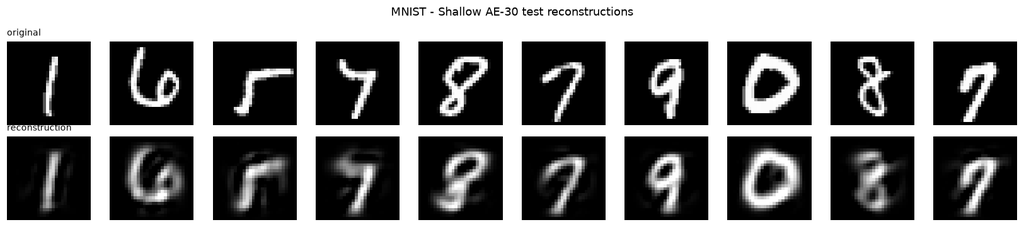

```
======================================================================
MNIST  |  Deep Dense AE-30
```

```
Model: "Deep_Dense_AE_30"
┏━━━━━━━━━━━━━━━━━━━━━━━━━━━━━━━━━━━━━━┳━━━━━━━━━━━━━━━━━━━━━━━━━━━━━┳━━━━━━━━━━━━━━━━━┓
┃ Layer (type)                         ┃ Output Shape                ┃         Param # ┃
┡━━━━━━━━━━━━━━━━━━━━━━━━━━━━━━━━━━━━━━╇━━━━━━━━━━━━━━━━━━━━━━━━━━━━━╇━━━━━━━━━━━━━━━━━┩
│ input_layer_1 (InputLayer)           │ (None, 784)                 │               0 │
├──────────────────────────────────────┼─────────────────────────────┼─────────────────┤
│ dense (Dense)                        │ (None, 256)                 │         200,960 │
├──────────────────────────────────────┼─────────────────────────────┼─────────────────┤
│ bottleneck (Dense)                   │ (None, 30)                  │           7,710 │
├──────────────────────────────────────┼─────────────────────────────┼─────────────────┤
│ dense_1 (Dense)                      │ (None, 256)                 │           7,936 │
├──────────────────────────────────────┼─────────────────────────────┼─────────────────┤
│ reconstruction (Dense)               │ (None, 784)                 │         201,488 │
└──────────────────────────────────────┴─────────────────────────────┴─────────────────┘
 Total params: 418,094 (1.59 MB)
 Trainable params: 418,094 (1.59 MB)
 Non-trainable params: 0 (0.00 B)
```

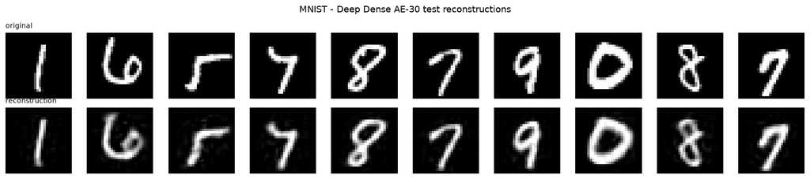

```
======================================================================
MNIST  |  Deep CNN AE-30
```

```
Model: "Deep_CNN_AE_30"
┏━━━━━━━━━━━━━━━━━━━━━━━━━━━━━━━━━━━━━━┳━━━━━━━━━━━━━━━━━━━━━━━━━━━━━┳━━━━━━━━━━━━━━━━━┓
┃ Layer (type)                         ┃ Output Shape                ┃         Param # ┃
┡━━━━━━━━━━━━━━━━━━━━━━━━━━━━━━━━━━━━━━╇━━━━━━━━━━━━━━━━━━━━━━━━━━━━━╇━━━━━━━━━━━━━━━━━┩
│ input_layer_2 (InputLayer)           │ (None, 28, 28, 1)           │               0 │
├──────────────────────────────────────┼─────────────────────────────┼─────────────────┤
│ conv2d (Conv2D)                      │ (None, 28, 28, 32)          │             320 │
├──────────────────────────────────────┼─────────────────────────────┼─────────────────┤
│ max_pooling2d (MaxPooling2D)         │ (None, 14, 14, 32)          │               0 │
├──────────────────────────────────────┼─────────────────────────────┼─────────────────┤
│ conv2d_1 (Conv2D)                    │ (None, 14, 14, 64)          │          18,496 │
├──────────────────────────────────────┼─────────────────────────────┼─────────────────┤
│ max_pooling2d_1 (MaxPooling2D)       │ (None, 7, 7, 64)            │               0 │
├──────────────────────────────────────┼─────────────────────────────┼─────────────────┤
│ flatten (Flatten)                    │ (None, 3136)                │               0 │
├──────────────────────────────────────┼─────────────────────────────┼─────────────────┤
│ bottleneck (Dense)                   │ (None, 30)                  │          94,110 │
├──────────────────────────────────────┼─────────────────────────────┼─────────────────┤
│ dense_2 (Dense)                      │ (None, 3136)                │          97,216 │
├──────────────────────────────────────┼─────────────────────────────┼─────────────────┤
│ reshape (Reshape)                    │ (None, 7, 7, 64)            │               0 │
├──────────────────────────────────────┼─────────────────────────────┼─────────────────┤
│ conv2d_transpose (Conv2DTranspose)   │ (None, 14, 14, 64)          │          36,928 │
├──────────────────────────────────────┼─────────────────────────────┼─────────────────┤
│ conv2d_transpose_1 (Conv2DTranspose) │ (None, 28, 28, 32)          │          18,464 │
├──────────────────────────────────────┼─────────────────────────────┼─────────────────┤
│ reconstruction (Conv2D)              │ (None, 28, 28, 1)           │             289 │
└──────────────────────────────────────┴─────────────────────────────┴─────────────────┘
 Total params: 265,823 (1.01 MB)
 Trainable params: 265,823 (1.01 MB)
 Non-trainable params: 0 (0.00 B)
```

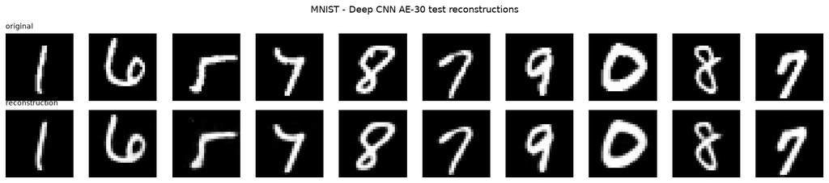

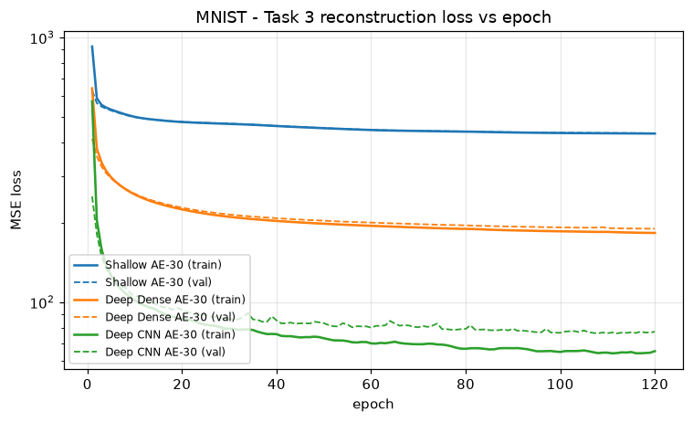

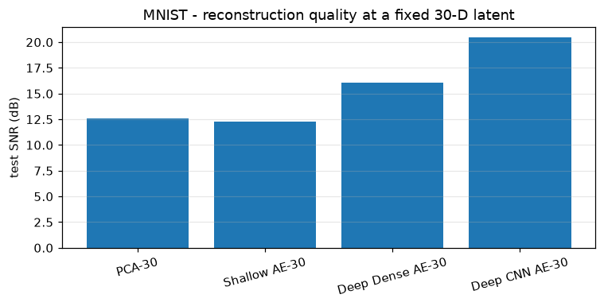

| model | params | train loss | val loss | train SNR (dB) | test SNR (dB) |
| --- | --- | --- | --- | --- | --- |
| PCA-30 | 0 | 406.4088 | 406.4178 | 12.59 | 12.58 |
| Shallow AE-30 | 47854 | 433.7708 | 434.9002 | 12.32 | 12.31 |
| Deep Dense AE-30 | 418094 | 182.6537 | 189.5218 | 16.23 | 16.10 |
| Deep CNN AE-30 | 265823 | 65.3113 | 77.3358 | 21.06 | 20.44 |

```python
t3_mnist, models_mnist = run_task3(DATA["mnist"])
t3_mnist
```

```
======================================================================
CIFAR10  |  Shallow AE-30
```

```
Model: "Shallow_Nonlinear_AE_30"
┏━━━━━━━━━━━━━━━━━━━━━━━━━━━━━━━━━━━━━━┳━━━━━━━━━━━━━━━━━━━━━━━━━━━━━┳━━━━━━━━━━━━━━━━━┓
┃ Layer (type)                         ┃ Output Shape                ┃         Param # ┃
┡━━━━━━━━━━━━━━━━━━━━━━━━━━━━━━━━━━━━━━╇━━━━━━━━━━━━━━━━━━━━━━━━━━━━━╇━━━━━━━━━━━━━━━━━┩
│ input_layer_3 (InputLayer)           │ (None, 784)                 │               0 │
├──────────────────────────────────────┼─────────────────────────────┼─────────────────┤
│ bottleneck (Dense)                   │ (None, 30)                  │          23,550 │
├──────────────────────────────────────┼─────────────────────────────┼─────────────────┤
│ reconstruction (Dense)               │ (None, 784)                 │          24,304 │
└──────────────────────────────────────┴─────────────────────────────┴─────────────────┘
 Total params: 47,854 (186.93 KB)
 Trainable params: 47,854 (186.93 KB)
 Non-trainable params: 0 (0.00 B)
```

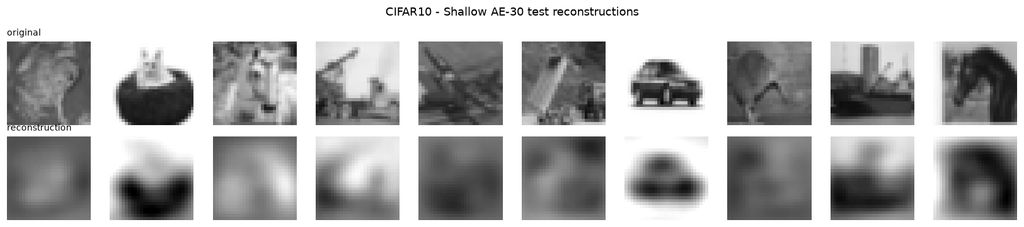

```
======================================================================
CIFAR10  |  Deep Dense AE-30
```

```
Model: "Deep_Dense_AE_30"
┏━━━━━━━━━━━━━━━━━━━━━━━━━━━━━━━━━━━━━━┳━━━━━━━━━━━━━━━━━━━━━━━━━━━━━┳━━━━━━━━━━━━━━━━━┓
┃ Layer (type)                         ┃ Output Shape                ┃         Param # ┃
┡━━━━━━━━━━━━━━━━━━━━━━━━━━━━━━━━━━━━━━╇━━━━━━━━━━━━━━━━━━━━━━━━━━━━━╇━━━━━━━━━━━━━━━━━┩
│ input_layer_4 (InputLayer)           │ (None, 784)                 │               0 │
├──────────────────────────────────────┼─────────────────────────────┼─────────────────┤
│ dense_3 (Dense)                      │ (None, 256)                 │         200,960 │
├──────────────────────────────────────┼─────────────────────────────┼─────────────────┤
│ bottleneck (Dense)                   │ (None, 30)                  │           7,710 │
├──────────────────────────────────────┼─────────────────────────────┼─────────────────┤
│ dense_4 (Dense)                      │ (None, 256)                 │           7,936 │
├──────────────────────────────────────┼─────────────────────────────┼─────────────────┤
│ reconstruction (Dense)               │ (None, 784)                 │         201,488 │
└──────────────────────────────────────┴─────────────────────────────┴─────────────────┘
 Total params: 418,094 (1.59 MB)
 Trainable params: 418,094 (1.59 MB)
 Non-trainable params: 0 (0.00 B)
```

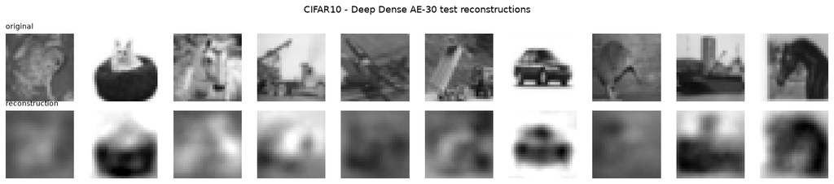

```
======================================================================
CIFAR10  |  Deep CNN AE-30
```

```
Model: "Deep_CNN_AE_30"
┏━━━━━━━━━━━━━━━━━━━━━━━━━━━━━━━━━━━━━━┳━━━━━━━━━━━━━━━━━━━━━━━━━━━━━┳━━━━━━━━━━━━━━━━━┓
┃ Layer (type)                         ┃ Output Shape                ┃         Param # ┃
┡━━━━━━━━━━━━━━━━━━━━━━━━━━━━━━━━━━━━━━╇━━━━━━━━━━━━━━━━━━━━━━━━━━━━━╇━━━━━━━━━━━━━━━━━┩
│ input_layer_5 (InputLayer)           │ (None, 28, 28, 1)           │               0 │
├──────────────────────────────────────┼─────────────────────────────┼─────────────────┤
│ conv2d_2 (Conv2D)                    │ (None, 28, 28, 32)          │             320 │
├──────────────────────────────────────┼─────────────────────────────┼─────────────────┤
│ max_pooling2d_2 (MaxPooling2D)       │ (None, 14, 14, 32)          │               0 │
├──────────────────────────────────────┼─────────────────────────────┼─────────────────┤
│ conv2d_3 (Conv2D)                    │ (None, 14, 14, 64)          │          18,496 │
├──────────────────────────────────────┼─────────────────────────────┼─────────────────┤
│ max_pooling2d_3 (MaxPooling2D)       │ (None, 7, 7, 64)            │               0 │
├──────────────────────────────────────┼─────────────────────────────┼─────────────────┤
│ flatten_1 (Flatten)                  │ (None, 3136)                │               0 │
├──────────────────────────────────────┼─────────────────────────────┼─────────────────┤
│ bottleneck (Dense)                   │ (None, 30)                  │          94,110 │
├──────────────────────────────────────┼─────────────────────────────┼─────────────────┤
│ dense_5 (Dense)                      │ (None, 3136)                │          97,216 │
├──────────────────────────────────────┼─────────────────────────────┼─────────────────┤
│ reshape_1 (Reshape)                  │ (None, 7, 7, 64)            │               0 │
├──────────────────────────────────────┼─────────────────────────────┼─────────────────┤
│ conv2d_transpose_2 (Conv2DTranspose) │ (None, 14, 14, 64)          │          36,928 │
├──────────────────────────────────────┼─────────────────────────────┼─────────────────┤
│ conv2d_transpose_3 (Conv2DTranspose) │ (None, 28, 28, 32)          │          18,464 │
├──────────────────────────────────────┼─────────────────────────────┼─────────────────┤
│ reconstruction (Conv2D)              │ (None, 28, 28, 1)           │             289 │
└──────────────────────────────────────┴─────────────────────────────┴─────────────────┘
 Total params: 265,823 (1.01 MB)
 Trainable params: 265,823 (1.01 MB)
 Non-trainable params: 0 (0.00 B)
```

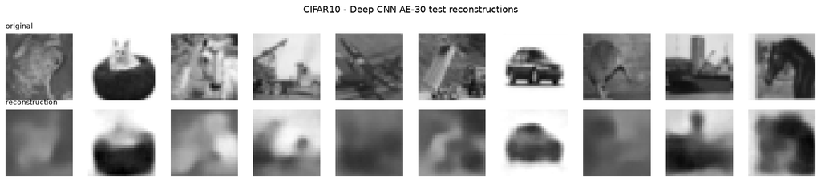

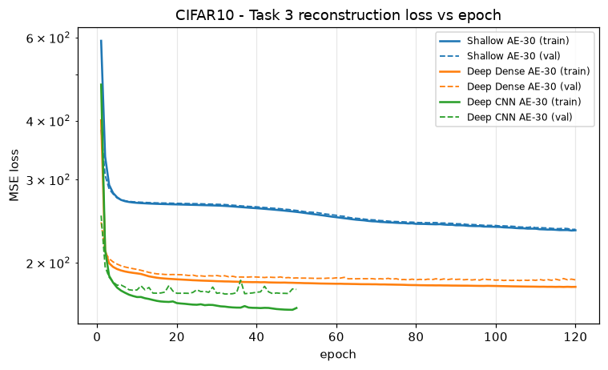

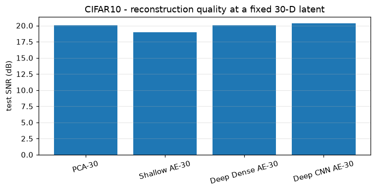

| model | params | train loss | val loss | train SNR (dB) | test SNR (dB) |
| --- | --- | --- | --- | --- | --- |
| PCA-30 | 0 | 181.1061 | 182.8840 | 20.06 | 20.06 |
| Shallow AE-30 | 47854 | 234.2366 | 235.3448 | 18.96 | 18.96 |
| Deep Dense AE-30 | 418094 | 177.7461 | 183.8937 | 20.10 | 20.04 |
| Deep CNN AE-30 | 265823 | 160.3327 | 175.5726 | 20.52 | 20.32 |

```python
t3_cifar, models_cifar = run_task3(DATA["cifar10"])
t3_cifar
```

```python
pd.concat({"MNIST": t3_mnist, "CIFAR10": t3_cifar}, names=["dataset"])
```

| dataset | model | params | train loss | val loss | train SNR (dB) | test SNR (dB) |
| --- | --- | --- | --- | --- | --- | --- |
| MNIST | PCA-30 | 0 | 406.4088 | 406.4178 | 12.59 | 12.58 |
|  | Shallow AE-30 | 47854 | 433.7708 | 434.9002 | 12.32 | 12.31 |
|  | Deep Dense AE-30 | 418094 | 182.6537 | 189.5218 | 16.23 | 16.10 |
|  | Deep CNN AE-30 | 265823 | 65.3113 | 77.3358 | 21.06 | 20.44 |
| CIFAR10 | PCA-30 | 0 | 181.1061 | 182.8840 | 20.06 | 20.06 |
|  | Shallow AE-30 | 47854 | 234.2366 | 235.3448 | 18.96 | 18.96 |
|  | Deep Dense AE-30 | 418094 | 177.7461 | 183.8937 | 20.10 | 20.04 |
|  | Deep CNN AE-30 | 265823 | 160.3327 | 175.5726 | 20.52 | 20.32 |

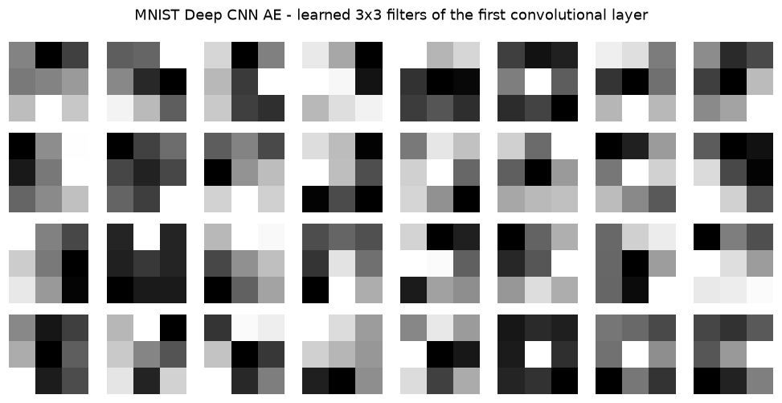

```python
# Learned first-layer filters of the convolutional autoencoder (MNIST).
cnn = models_mnist["Deep CNN AE-30"]
kernel = cnn.layers[1].get_weights()[0]        # first Conv2D kernel: (3, 3, 1, 32)
fig, axes = plt.subplots(4, 8, figsize=(9, 4.6))
for i, ax in enumerate(axes.flat):
    ax.imshow(kernel[..., 0, i], cmap="gray")
    ax.axis("off")
fig.suptitle("MNIST Deep CNN AE - learned 3x3 filters of the first convolutional layer")
plt.tight_layout(); plt.show()
```

### References

- H. Bourlard and Y. Kamp. *Auto-association by multilayer perceptrons and singular value decomposition.* Biological Cybernetics, 1988.
- P. Baldi and K. Hornik. *Neural networks and principal component analysis: learning from examples without local minima.* Neural Networks, 1989.
- A. Bjorck and G. Golub. *Numerical methods for computing angles between linear subspaces.* Mathematics of Computation, 1973.
- N. Halko, P. G. Martinsson and J. A. Tropp. *Finding structure with randomness: probabilistic algorithms for constructing approximate matrix decompositions.* SIAM Review, 2011.